# tinkerbell map

### **[home](https://olssonmatt.github.io/)** / **[portfolio](https://olssonmatt.github.io/portfolio.html)** / **[notes](https://olssonmatt.github.io/notes.html)** / **[contact](https://olssonmatt.github.io/contact.html)**

- inspiration for the quick project: @MathLetters on Instragram, & [chaoticforms](https://www.chaoticforms.com)
- purpose: a fun project done to review coding iterative functions and have some cool output

## defintions

- **discrete time system**
  - views values of variables output at distinct times, in which they are unchanged though some throughout a 'time period', or are separated usually by some 'time period'
  - in this case, the system of equations output a set of coordinates that are then used in the next function
  - ihis iteration is counted as a time period
  - in comparison, a continuous time system would be one that could be represented by a function
- **iterative method**
  - a method that uses an initial set of values to generate a new set of values that are to be used
  - these new values can then be used, and so on and so on
  - in this example, the x-y coordinates can begin anywhere and the variables can be chosen by the user
- **dynamical system**
  - a function that describes the time dependence of a point in space
  - in this example, this is a discrete system in 2 dimensional space
- **chaotic map**
  - a map (evolution function) that exhibits chaotic behaviour
  - chaotic behaviour focuses on patterns and deterministic laws of dynamical systems that are highly sensitive to initial conditions
  - these we once thought of as completely random states of disorder or irregularities

## code

- the code below looks at plotting these systems of equations and serves as an excerise in python
- the output of the graphs might be used in an art project as well
- possibly look at varying the parameters as well as animating the output graphs

#### further reading

- [finance maps](http://www.internonlinearscience.org/upload/papers/20110308103218810.pdf)
- perhaps looking into continuous chaotic systems
- Lorenz systems and physical applications of it

#### bibliography

1. [chaotic maps](https://en.wikipedia.org/wiki/List_of_chaotic_maps)
2. [tinkerbell maps](https://en.wikipedia.org/wiki/Tinkerbell_map)
3. [discrete & continuous time](https://en.wikipedia.org/wiki/Discrete_time_and_continuous_time)
4. [iterative method](https://en.wikipedia.org/wiki/Iterative_method)
5. [dynamical system](https://en.wikipedia.org/wiki/Dynamical_system)

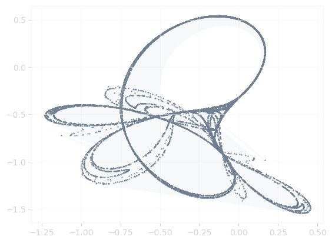

```python
import numpy as np
import matplotlib as mpl
import matplotlib.pyplot as plt

#initial conditions
#x,y = initial coordinates; xt,yt = array of output coordinates a,b,c,d = variables; t=number of iterations
#some interesting coniditions:
# x, y, a, b, c, d = -0.7, -0.6, 1, -0.07, 0.3, 0.5

x, y = -0.72, -0.64
a, b, c, d = 0.9, -0.6013, 2, 0.5
t=20000
xt=[]
yt=[]

for i in range(0,t):
    xn =x
    x = xn**2 - y**2 + a*xn + b*y
    y = 2*xn*y + c*xn + d*y
    xt += [x]
    yt += [y]

fig, ax = plt.subplots()
ax.scatter(xt,yt,
           s=1,
           marker='1',
           c='slategrey',
           alpha=1)
ax.plot(xt,yt,
           c='slategrey',
           alpha=0.05)
ax.grid(c='whitesmoke',alpha=0.5)
ax.set_facecolor('w')
ax.spines['top'].set_color('whitesmoke')
ax.spines['bottom'].set_color('whitesmoke')
ax.spines['left'].set_color('whitesmoke')
ax.spines['right'].set_color('whitesmoke')
ax.tick_params(axis='x', colors='lightgray')
ax.tick_params(axis='y', colors='lightgray')
#plt.xlim([-0.04,0.025])
#plt.ylim([-0.01,0.02])
plt.show()
```